# 46_shifted_exp_log

## 46_shifted_exp_log

#### Question

1. Match the following graphs to their equations. I’ve shown the asymptotes as dotted red lines.

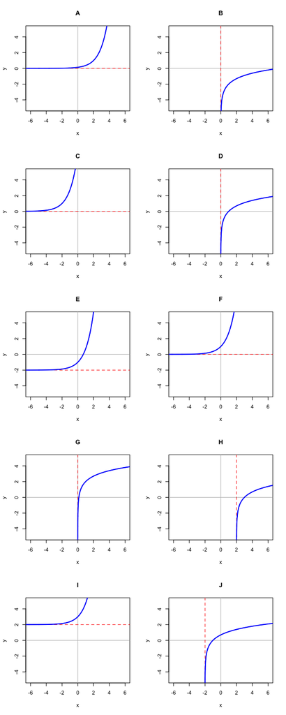

   1. $y=e^{x}-2$
   2. $y=\ln(x-2)$
   3. $y=e^{x}+2$
   4. $y=e^{x+2}$
   5. $y=\ln(x)-2$
   6. $y=\ln(x)$
   7. $y=e^{x}$
   8. $y=\ln(x)+2$
   9. $y=\ln(x+2)$
   10. $y=e^{x-2}$

#### Question

2. Match the following graphs to their equations. I’ve shown the asymptotes as dotted red lines.

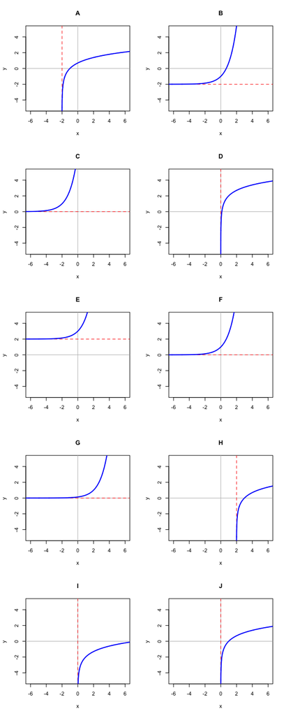

   1. $y=e^{x-2}$
   2. $y=\ln(x+2)$
   3. $y=e^{x}$
   4. $y=e^{x}+2$
   5. $y=\ln(x)+2$
   6. $y=e^{x}-2$
   7. $y=e^{x+2}$
   8. $y=\ln(x)$
   9. $y=\ln(x-2)$
   10. $y=\ln(x)-2$

#### Question

3. Match the following graphs to their equations. I’ve shown the asymptotes as dotted red lines.

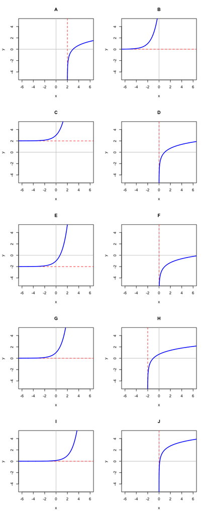

   1. $y=\ln(x)$
   2. $y=e^{x}-2$
   3. $y=\ln(x)-2$
   4. $y=\ln(x)+2$
   5. $y=e^{x-2}$
   6. $y=e^{x+2}$
   7. $y=e^{x}+2$
   8. $y=\ln(x-2)$
   9. $y=\ln(x+2)$
   10. $y=e^{x}$

#### Question

4. Match the following graphs to their equations. I’ve shown the asymptotes as dotted red lines.

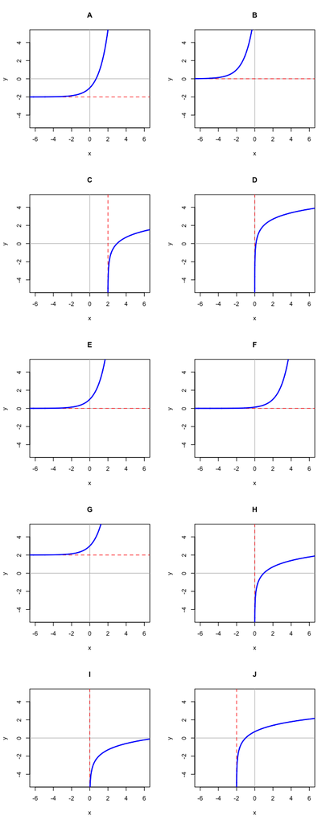

   1. $y=e^{x}-2$
   2. $y=e^{x}+2$
   3. $y=e^{x}$
   4. $y=\ln(x+2)$
   5. $y=\ln(x-2)$
   6. $y=e^{x-2}$
   7. $y=e^{x+2}$
   8. $y=\ln(x)$
   9. $y=\ln(x)-2$
   10. $y=\ln(x)+2$

#### Question

5. Match the following graphs to their equations. I’ve shown the asymptotes as dotted red lines.

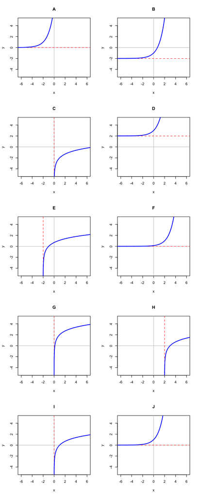

   1. $y=\ln(x)+2$
   2. $y=\ln(x)$
   3. $y=\ln(x+2)$
   4. $y=\ln(x)-2$
   5. $y=e^{x}+2$
   6. $y=e^{x-2}$
   7. $y=\ln(x-2)$
   8. $y=e^{x+2}$
   9. $y=e^{x}-2$
   10. $y=e^{x}$

#### Question

6. Match the following graphs to their equations. I’ve shown the asymptotes as dotted red lines.

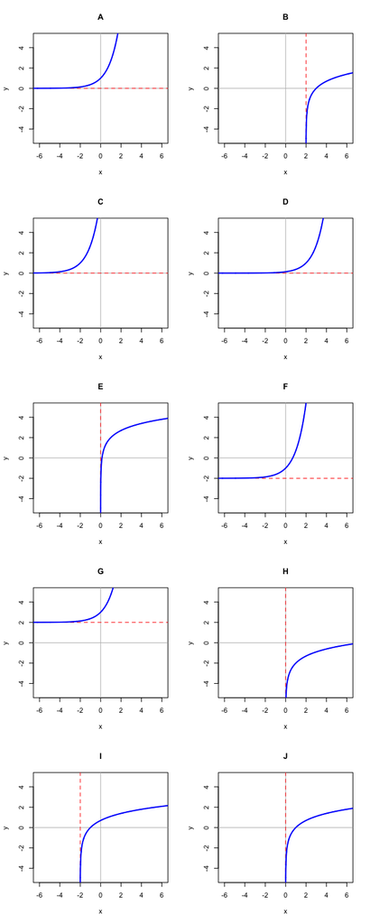

   1. $y=\ln(x-2)$
   2. $y=\ln(x)+2$
   3. $y=e^{x}+2$
   4. $y=e^{x+2}$
   5. $y=\ln(x)$
   6. $y=e^{x}-2$
   7. $y=e^{x-2}$
   8. $y=e^{x}$
   9. $y=\ln(x)-2$
   10. $y=\ln(x+2)$

#### Question

7. Match the following graphs to their equations. I’ve shown the asymptotes as dotted red lines.

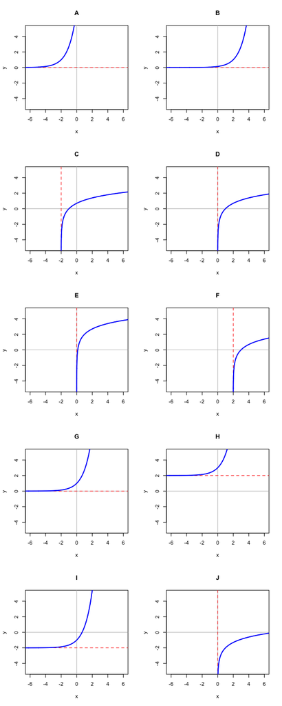

   1. $y=\ln(x)+2$
   2. $y=\ln(x-2)$
   3. $y=\ln(x+2)$
   4. $y=e^{x}$
   5. $y=e^{x}-2$
   6. $y=e^{x-2}$
   7. $y=e^{x}+2$
   8. $y=e^{x+2}$
   9. $y=\ln(x)-2$
   10. $y=\ln(x)$

#### Question

8. Match the following graphs to their equations. I’ve shown the asymptotes as dotted red lines.

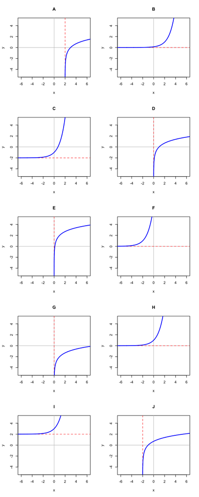

   1. $y=\ln(x)-2$
   2. $y=\ln(x)+2$
   3. $y=\ln(x-2)$
   4. $y=e^{x-2}$
   5. $y=e^{x+2}$
   6. $y=\ln(x+2)$
   7. $y=e^{x}$
   8. $y=e^{x}+2$
   9. $y=e^{x}-2$
   10. $y=\ln(x)$